# Multiple Linear Regression and Outcome Transformation

Yeojoo Lee

2026-09-28

## Overview

This project applies multiple linear regression to examine whether post-treatment pathology levels can be predicted from pre-treatment symptom ratings of thinking disturbance and hostile suspiciousness.

The analysis was completed as part of biostatistics coursework and demonstrates my experience with R programming, regression modeling, model diagnostics, and outcome transformation.

## Data

The dataset used in this analysis was provided as part of coursework and is not included in this repository.

## Statistical Methods

The primary outcome was the level of pathology six months after treatment.

The predictors were:

- **X1:** pre-treatment symptom rating of thinking disturbance
- **X2:** pre-treatment symptom rating of hostile suspiciousness

The analysis includes:

- Multiple linear regression
- Interpretation of regression coefficients
- Assessment of regression assumptions
- Residual diagnostics
- Log transformation of the outcome
- Comparison of model assumptions before and after transformation

## Analysis

### Multiple Linear Regression

A multiple linear regression model was fitted using pathology level (Y) as the outcome and pre-treatment symptom ratings of thinking disturbance (X1) and hostile suspiciousness (X2) as predictors.

```r
psycho <- read.csv("psycho.csv")

model <- lm(Y ~ X1 + X2, data = psycho)

summary(model)
```

```
##
## Call:
## lm(formula = Y ~ X1 + X2, data = psycho)
##
## Residuals:
##     Min      1Q  Median      3Q     Max
## -22.137  -9.490  -2.019   6.438  39.407
##
## Coefficients:
##             Estimate Std. Error t value Pr(>|t|)
## (Intercept)  -0.6354    20.9683  -0.030  0.97595
## X1           23.4514     6.8385   3.429  0.00122 **
## X2           -7.0726     3.0109  -2.349  0.02282 *
## ---
## Signif. codes:  0 '***' 0.001 '**' 0.01 '*' 0.05 '.' 0.1 ' ' 1
##
## Residual standard error: 14.86 on 50 degrees of freedom
## Multiple R-squared:  0.1997, Adjusted R-squared:  0.1677
## F-statistic: 6.238 on 2 and 50 DF,  p-value: 0.003815
```

### Regression Equation

The fitted regression model was:

$$Y = -0.6354 + 23.4514X_1 - 7.0726X_2 + \epsilon$$
### Interpretation of Regression Coefficients

Holding X2 constant, a one-unit increase in thinking disturbance (X1) was associated with an estimated 23.45-unit increase in pathology level (Y). This association was statistically significant (p = 0.001).

Holding X1 constant, a one-unit increase in hostile suspiciousness (X2) was associated with an estimated 7.07-unit decrease in pathology level (Y). This association was statistically significant (p = 0.02).

### Model Diagnostics

The assumptions of multiple linear regression were assessed using residual diagnostic plots, including a residuals-versus-predicted values plot, a histogram of residuals, and a Q-Q plot.

The residuals were examined to assess linearity, homoscedasticity, and normality.

Independence was considered based on the study design and data collection process.

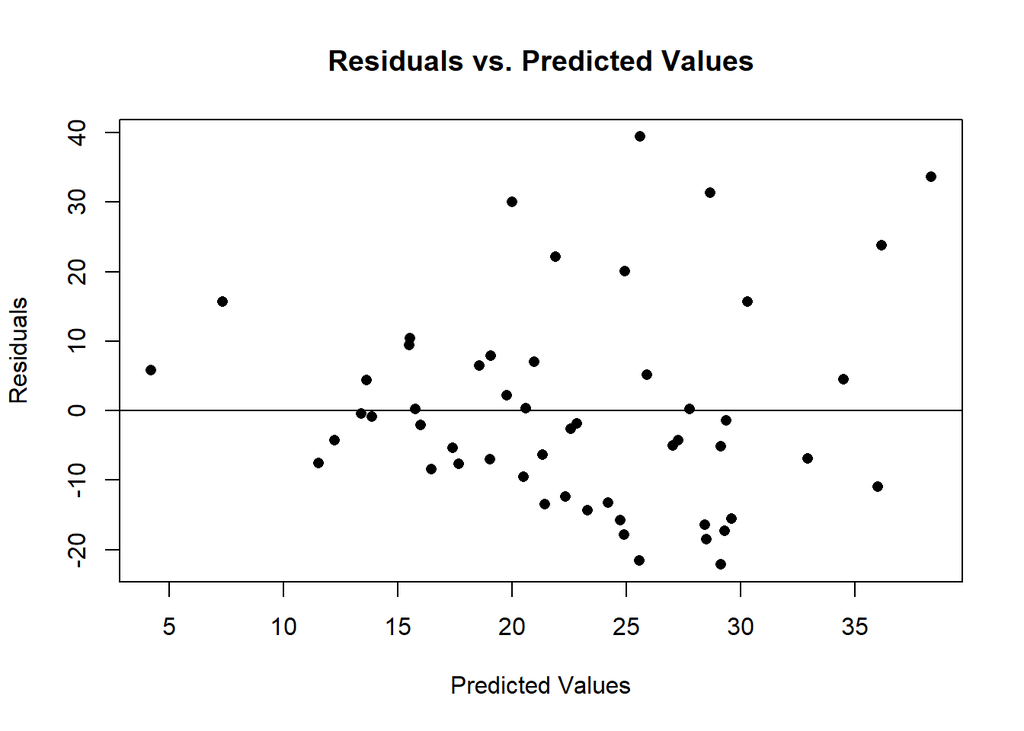

```r
p <- predict(model)
r <- resid(model)

plot(p, r,
     main = "Residuals vs. Predicted Values",
     xlab = "Predicted Values",
     ylab = "Residuals",
     pch = 16)

abline(h = 0)
```

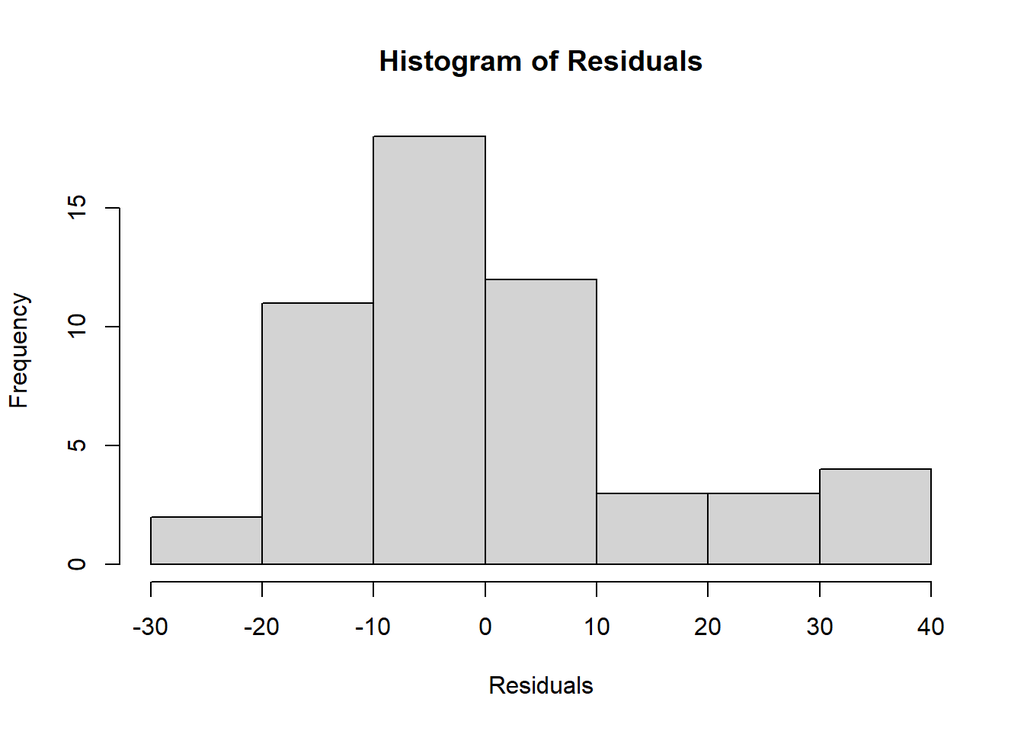

```r
hist(r,
     main = "Histogram of Residuals",
     xlab = "Residuals",
     ylab = "Frequency")
```

```r
library(car)
```

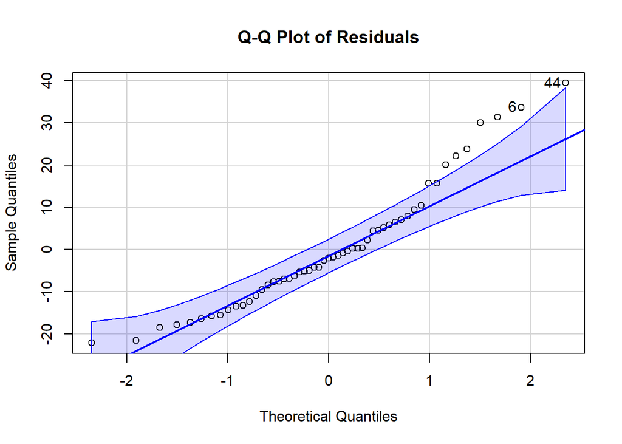

```
## [1] 44  6
```

```r
qqPlot(r,
       main = "Q-Q Plot of Residuals",
       xlab = "Theoretical Quantiles",
       ylab = "Sample Quantiles")
```

### Log Transformation of the Outcome

A log transformation was applied to the outcome variable to assess whether the regression assumptions could be improved.

```r
model_log <- lm(log(Y) ~ X1 + X2, data = psycho)

summary(model_log)
```

```
##
## Call:
## lm(formula = log(Y) ~ X1 + X2, data = psycho)
##
## Residuals:
##     Min      1Q  Median      3Q     Max
## -1.5804 -0.4928  0.0470  0.4812  1.1979
##
## Coefficients:
##             Estimate Std. Error t value Pr(>|t|)
## (Intercept)   2.2472     0.9125   2.463  0.01728 *
## X1            0.8562     0.2976   2.877  0.00589 **
## X2           -0.2895     0.1310  -2.210  0.03175 *
## ---
## Signif. codes:  0 '***' 0.001 '**' 0.01 '*' 0.05 '.' 0.1 ' ' 1
##
## Residual standard error: 0.6466 on 50 degrees of freedom
## Multiple R-squared:  0.1559, Adjusted R-squared:  0.1222
## F-statistic: 4.619 on 2 and 50 DF,  p-value: 0.01443
```

### Log-Transformed Regression Equation

The fitted regression model after transforming the outcome was:

$$\log(Y) = 2.2472 + 0.8562X_1 - 0.2895X_2 + \epsilon$$
### Interpretation of Regression Coefficients

Holding X2 constant, a one-unit increase in thinking disturbance (X1) was associated with a multiplicative change of exp(0.8562) ≈ 2.35 in the expected pathology level.

Holding X1 constant, a one-unit increase in hostile suspiciousness (X2) was associated with a multiplicative change of exp(-0.2895) ≈ 0.75 in the expected pathology level, corresponding to approximately a 25% decrease.

### Diagnostics After Log Transformation

The residuals from the log-transformed model were examined using the same diagnostic plots to assess whether the model assumptions improved.

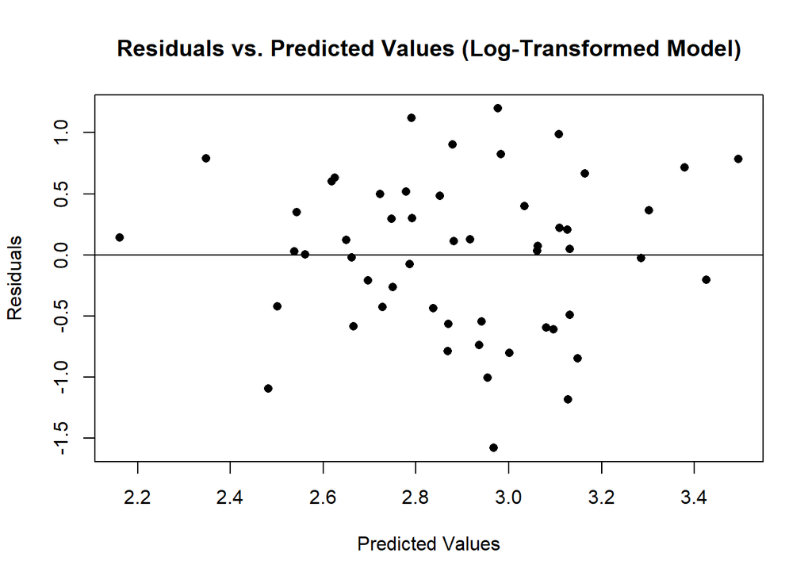

```r
p_log <- predict(model_log)
r_log <- resid(model_log)

plot(p_log, r_log,
     main = "Residuals vs. Predicted Values (Log-Transformed Model)",
     xlab = "Predicted Values",
     ylab = "Residuals",
     pch = 16)

abline(h = 0)
```

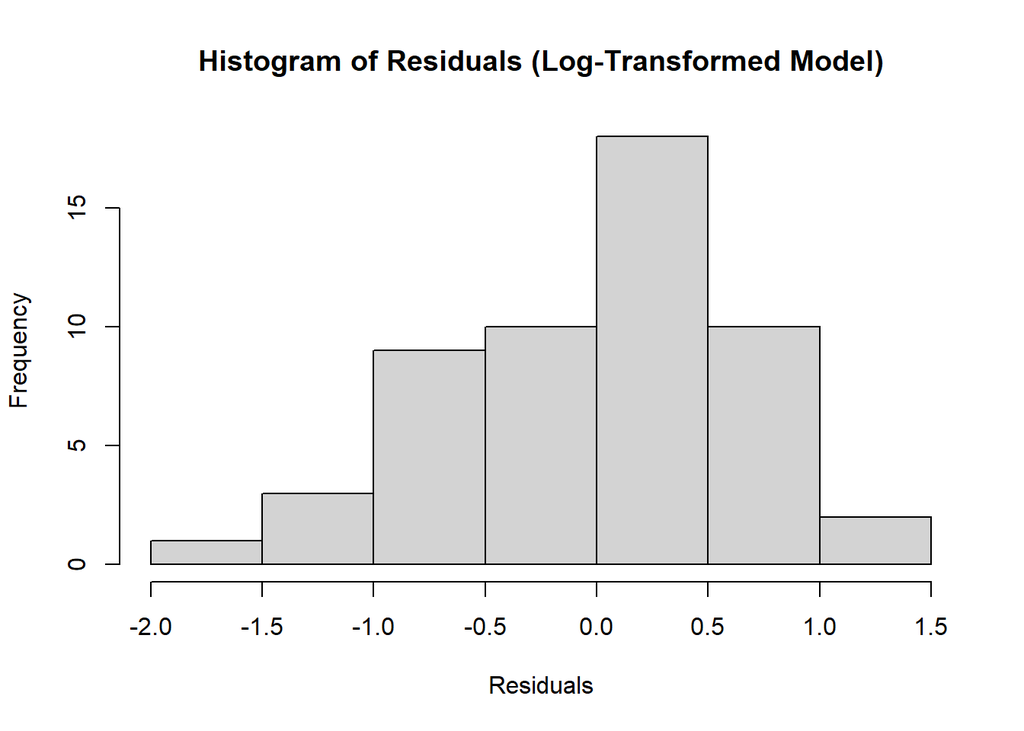

```r
hist(r_log,
     main = "Histogram of Residuals (Log-Transformed Model)",
     xlab = "Residuals",
     ylab = "Frequency")
```

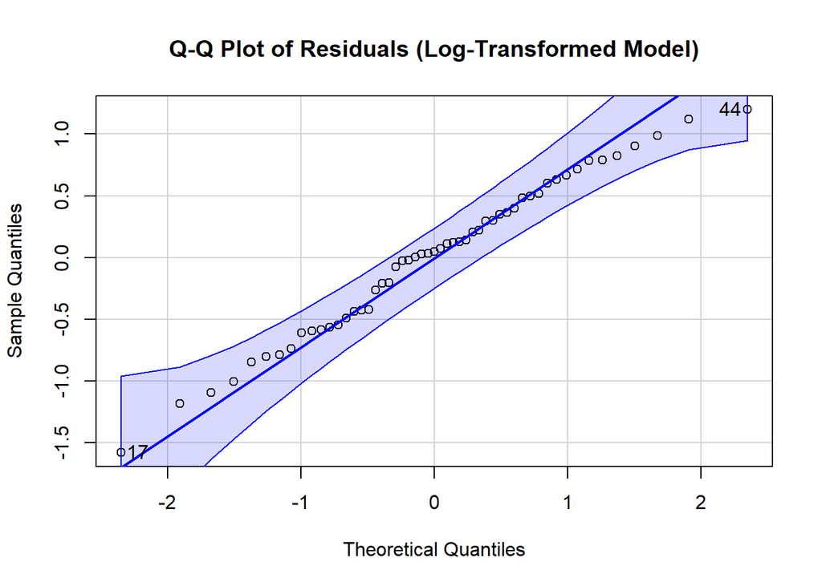

```
## [1] 17 44
```

```r
qqPlot(r_log,
       main = "Q-Q Plot of Residuals (Log-Transformed Model)",
       xlab = "Theoretical Quantiles",
       ylab = "Sample Quantiles")
```

## Conclusion

The original multiple linear regression model showed evidence of non-constant residual variance and departures from normality.

After applying a log transformation to the outcome, the residual diagnostics indicated improved model assumptions, including more consistent residual variance and improved approximate normality.

This analysis demonstrates the use of multiple linear regression, model diagnostics, and outcome transformation in R.